# Biometrie onderzoek

2026-04-21

## Inleiding

GEEF EEN HEEL KORTE INLEINDING VAN JE ONDERZOEK

Wij gaan onderzoeken of er een verschil zit in de arm/been ratio tussen mannen en vrouwen. Het meten en noteren van deze gegevens wordt afgewisseld onder de studenten. Dit leidt tot de onderzsoekvraag: Zit er een verschil in de arm/been ratio tussen man en vrouw? Onze hypothese is dat mannen een hogere arm/been ratio zullen hebben dan vrouwen. Onze nul-hypothese is dat er geen verschil in de arm/been ratio zit tussen mannen en vrouwen.

GEEF HIER JE ONDERZOEKSVRAAG:  
Zit er een verschil in de arm/been ratio tussen man en vrouw?

GEEF HIER JE HYPOTHESE:  
Mannen zullen een hogere arm/been ratio hebben dan vrouwen

GEEF HIER JE NULHYPOTHESE:  
Er zit geen verschil in de arm/been ratio tussen mannen en vrouwen

### Ontwerp van het experiment

Arm en been lengtes worden gemeten, vervolgens zal hiervan de ratio uitgerekend worden en zal dit in een plot weergegeven worden om te kijken of er een verschil zit tussen mannen en vrouwen.

### Ontwerp het protocol

Bij testsubjecten zullen de lengte van de been van enkel tot heup en de lengte van de arm van pols tot oksel gemeten worden. Ook zal gevraagd worden naar het geslacht

##### Benodigdheden

1. Maatlat, schuifmaat of meetlint.
2. Spreadsheet om resultaten vast te leggen, met toegang hiertoe op locaties zonder internet-toegang.

##### Data verzamelen

Ga op de campus opzoek naar vrijwillgers die meewillen doen aan het experiment. Vraag beleefd of ze willen participeren in een klein wetenschappelijk onderzoekje voor school waarbij de lengte van de armen en benen opgenomen zullen worden. Is het antwoord nee, dan groet je vriendelijk en zoek je verder.  
Is het antwoord ja, dan vraag je of de proefpersoon rechtop wilt gaan staan en zijn arm voruit wilt strekken. Vervolgens meet je de lengte van de pols tot de oksel en en de lengte van de enkel tot de heup. Deze leg je vast in de spreadsheet, samen met je naam en een identifier (géén naam!) van de proefpersoon. Ten slotte vraag je aan de proefpersoon zijn/haar/hun sexe en legt deze vast. Wil de proefpersoon deze niet geven, of is die nonbinair, dan leg je dit vast als “anders/onbekend”. Het “parallel groepje” (dat niet jouw bevindingen mag horen) doet dezelfde meting en slaat deze met dezelfde participant identifier op.

## Uitvoering

Je moet de onderzoeksresultaten in deze vorm opslaan:

[output not shown]

## Analyse

### Lees je eigen data in

Om data vanuit een tekstbestand in te lezen kan je dit codeblok gebruiken, aannemend dat je data er exact zo uitzien als in bovenstaande voorbeeld:

```r
library(ggplot2)
library(tidyverse)
library(tidyr)
gegevens <- read.csv("arm_en_beendata.csv")
gegevens$persoonnummer <- factor(gegevens$persoonnummer)
gegevens$gender <- factor(gegevens$gender, levels=c("m", "v"), labels = c("Male", "Female"))



data_long <- pivot_longer(gegevens,
                          cols = c(lengte_arm1, lengte_been1, gemeten_door1,
                          lengte_arm2, lengte_been2, gemeten_door2),
                          names_to = c(".value", "meting"),
                          names_pattern = "(.*)(1|2)"
  )

data_long$ratio <- data_long$lengte_arm/data_long$lengte_been
```

Let op: als je missende data hebt moet je die specificeren door dit argument toe te voegen: `na.strings = "<jouw NA symbool>"`

### Beschrijvende statistiek

In de grafiek en tabel is te zien dat de ratio verschilt tussen mannen en vrouwen. De arm/been ratio ligt hoger bij vrouwen dan bij mannen, ook al is de grootte van dit verschil wel erg varierend tussen de twee metingen.

```r
gender_split_data <- split(x = data_long,
      f = data_long$gender)

#apply a function to report means of both measurements
sapply(X = gender_split_data,
       FUN = function(x){
           c(arm_length = mean(x$lengte_arm),
             leg_length = mean(x$lengte_been),
             ratio = mean(x$ratio))
       })
```

```
##                  Male     Female
## arm_length 51.2631579 50.6904762
## leg_length 96.9736842 92.6904762
## ratio       0.5301009  0.5483288
```

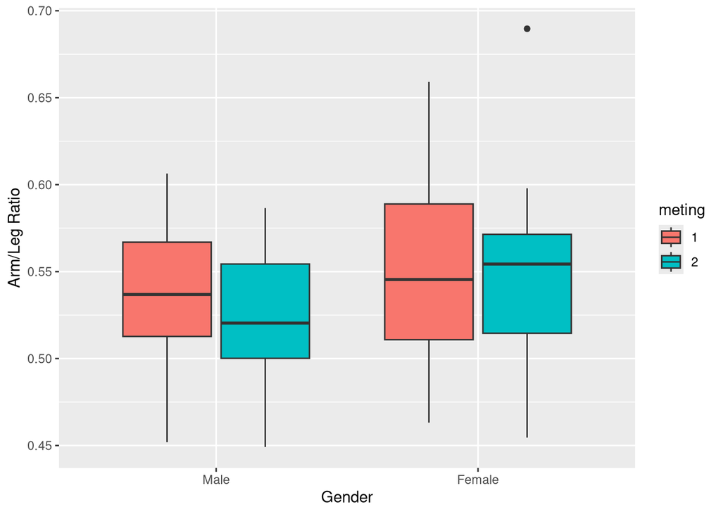

```r
ggplot(data_long, aes(x=gender, y=ratio, fill=meting))+
  geom_boxplot() +
  xlab("Gender") +
  ylab("Arm/Leg Ratio")
```

### Welke verdeling?

Hoe kleiner de steekproefgrootte (*sample size*) hoe lastiger het is de onderliggende verdeling vast te stellen. Speel maar eens met dit blokje code, en verander de steekproefgrootte (`n=`) in de `rnorm()` functie en de `breaks=` in de `hist()` functie. Neem voor *n* bijvoorbeeld achtereenvolgens 10, 100, 1000, 10000, 10000 en voor *breaks* 5, 10, 50. Wanneer zie je een echte normaalverdeling verschijnen?

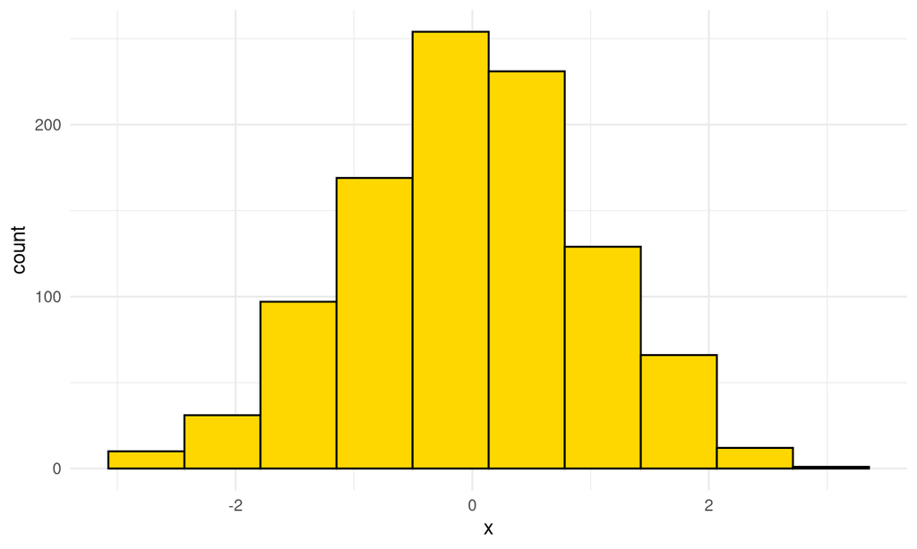

```r
hist_data <- data.frame(x = rnorm(n = 1000))
ggplot(data = hist_data,
       mapping = aes(x = x)) +
    geom_histogram(bins = 10, fill = "gold", colour = "black") +
    theme_minimal()
```

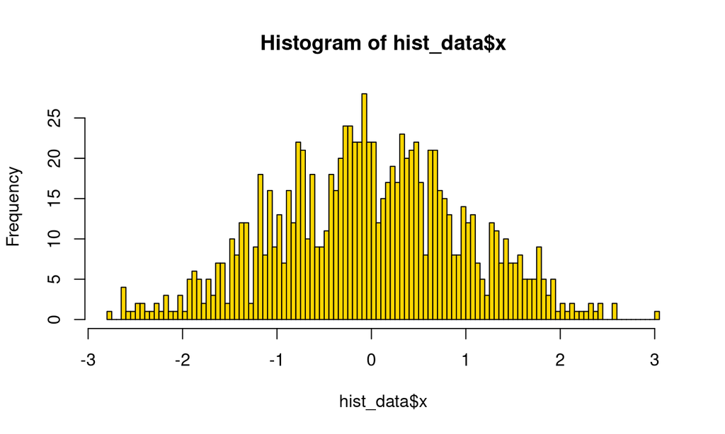

```r
hist(hist_data$x,
     breaks = 100,
     col = "gold",
     border = "black")
```

```r
help(hist)
```

**Dit *experiment* met de argumenten van `rnorm()` en `hist()` moet je opnemen in je eigen RMarkdown.**  
Beantwoord deze vragen:

1. Wat gebeurt er met de vorm van de verdeling als `n` groter wordt?  
   Dan wordt de vorm meer symmetrisch.
2. Wat gebeurt er met de spreiding van de data (x-as) als `n` groter wordt, en kan je dat verklaren?  
   Die wordt ook groter, aangezien het de kans op een hele verre uitschieter ook vergroot.
3. Waarom is bij zelfde instellingen voor `n` en `breaks` de uitkomst toch verschillend?  
   Omdat n het aantal datapunten aangeeft en breaks het aantal cellen aangeeft.
4. Welke minimale `n` geeft het meeste kans om een echte normaalverdeling te zien?
6. Wat voor bijzonders is er aan de hand met het `breaks` argument? Geeft de documentatie daar een verklaring voor?  
   Het is alleen een suggestie als je een getal gebruikt.

### Bronnen van variatie

De biologische variatie tussen man en vrouw en bij beiden onderling zal allebij waarschijnlijk veroorzaakt worden door overerving.

### De hypothese aannemen?

```r
shapiro.test(data_long$ratio)
```

```
##
##  Shapiro-Wilk normality test
##
## data:  data_long$ratio
## W = 0.98232, p-value = 0.3356
```

De p waarde ligt boven de 0.05, dus de t-test kan worden uitgevoerd

```r
female_ratios <- subset(data_long,
                        subset = gender == "Female",
                        select = ratio,
                        drop = T) # drop = T forces ro a vector
male_ratios <- subset(data_long,
                        subset = gender == "Male",
                        select = ratio,
                        drop = T)
t.test(female_ratios, male_ratios)
```

```
##
##  Welch Two Sample t-test
##
## data:  female_ratios and male_ratios
## t = 1.7874, df = 76.547, p-value = 0.07783
## alternative hypothesis: true difference in means is not equal to 0
## 95 percent confidence interval:
##  -0.002081073  0.038536941
## sample estimates:
## mean of x mean of y
## 0.5483288 0.5301009
```

De p waarde is net hoger dan 0.05, dus zal de nul-hypothese niet verworpen worden en is er dus geen significant bewijs dat er een arm/been ratio verschil is tussen mannen en vrouwen

```r
wilcox.test(female_ratios, male_ratios)
```

```
##
##  Wilcoxon rank sum test with continuity correction
##
## data:  female_ratios and male_ratios
## W = 953.5, p-value = 0.1353
## alternative hypothesis: true location shift is not equal to 0
```

Ook deze zit niet in het significante bereik.

## Reflectie op het experiment

Bespreek in je groep de volgende vragen en voeg de antwoorden toe aan je uitgewerkte onderzoeksdocument.

1. Zijn de metingen tussen de verschillende meters ook (significant) verschillend? Zo ja, waardoor zou je de verschillen kunnen verklaren?

```r
meter1_ratios <- subset(data_long,
                        subset = meting == 2,
                        select = ratio,
                        drop = T) # drop = T forces ro a vector
meter2_ratios <- subset(data_long,
                        subset = meting == 1,
                        select = ratio,
                        drop = T)
t.test(meter1_ratios, meter2_ratios)
```

```
##
##  Welch Two Sample t-test
##
## data:  meter1_ratios and meter2_ratios
## t = -0.66005, df = 77.999, p-value = 0.5112
## alternative hypothesis: true difference in means is not equal to 0
## 95 percent confidence interval:
##  -0.02778942  0.01395073
## sample estimates:
## mean of x mean of y
## 0.5362109 0.5431302
```

De p waarde ligt ver boven de 0.05, dus deze zijn niet significant. Echter is het wel het geval dat meter 1 en 2 niet altijd dezelfde zijn. Als je per persoon kijkt naar de metingen lijkt het wel alsof dit een significante impact heeft op de resultaten

2. Onderzoek de verschillen tussen mannen en vrouwen met betrekking tot arm lengte, been lengte en de ratio.  
   De data die we hebben verzameld toont geen significante relatie aan tussen arm/been ratio.

```r
female_arm <- subset(data_long,
                        subset = gender == "Female",
                        select = lengte_arm,
                        drop = T) # drop = T forces ro a vector
male_arm <- subset(data_long,
                        subset = gender == "Male",
                        select = lengte_arm,
                        drop = T)
t.test(female_arm, male_arm)
```

```
##
##  Welch Two Sample t-test
##
## data:  female_arm and male_arm
## t = -0.67866, df = 77.515, p-value = 0.4994
## alternative hypothesis: true difference in means is not equal to 0
## 95 percent confidence interval:
##  -2.252815  1.107452
## sample estimates:
## mean of x mean of y
##  50.69048  51.26316
```

```r
female_leg <- subset(data_long,
                        subset = gender == "Female",
                        select = lengte_been,
                        drop = T) # drop = T forces ro a vector
male_leg <- subset(data_long,
                        subset = gender == "Male",
                        select = lengte_been,
                        drop = T)
t.test(female_leg, male_leg)
```

```
##
##  Welch Two Sample t-test
##
## data:  female_leg and male_leg
## t = -3.2035, df = 74.132, p-value = 0.002002
## alternative hypothesis: true difference in means is not equal to 0
## 95 percent confidence interval:
##  -6.947228 -1.619188
## sample estimates:
## mean of x mean of y
##  92.69048  96.97368
```

De data toont ook niet dat er een significant verschil is in arm lengte, echter heeft de been lengte een p waarde van onder de 0.05, dus is het aannemelijk dat hier daadwerkelijk een significant verschil in zit tussen man en vrouw

3. Zou je het protocol aanpassen na deze ervaring, of was hij voldoende duidelijk en reproduceerbaar?  
   Ja, vooral op het moment dat mensen meerder lagen aan hebben is het moeijlijk om consistent dezelfde afstanden te meten. Echter is het vragen of mensen kleding uit willen doen dan weer niet heel gepast, dus is het moeilijk hierin een balans te vinden.

#### Wat je moet inleveren

Voor de verwerking en analyse van je eigen data maak je gebruik van het aangeleverde template RMarkdown document. Daarin doorloop je dezelfde onderzoek stappen als hieronder, maar dan met je eigen data. Aan het einde van de dag gaat dat document, in originele en “geknitte” vorm, samen met je databestand, in een git repo die is opgezet volgens voorschift in de cursushandleiding. De link hiernaar toe gaat in je portfolio op eJournal. Let op dat je *alle* stappen hebt doorlopen voordat je inlevert. Gebruik ook de RStudio spellingscontrole!  
Vergeet niet jullie namen en studentnummers bovenaan de markdown te zetten!